# Julia Quick Start

Download Julia here: https://julialang.org/downloads/

Open the Julia application. You should see a startup banner similar to this:

```
               _
   _       _ _(_)_     |  Documentation: https://docs.julialang.org
  (_)     | (_) (_)    |
   _ _   _| |_  __ _   |  Type "?" for help, "]?" for Pkg help.
  | | | | | | |/ _` |  |
  | | |_| | | | (_| |  |  Version x.y.z (YYYY-MM-DD)
 _/ |\__'_|_|_|\__'_|  |  Official https://julialang.org/ release
|__/                   |

julia>
```

*Try typing in 2+2 and hitting enter, or π or other commands to play around for a second*

## Install Visual Studio Code (VS Code)

*After* confirming Julia runs, download and install VS Code: https://code.visualstudio.com/

- Open VS Code.
- Click on the **Extensions** icon in the Activity Bar on the side of the window. It looks like four squares forming a larger square, with the top-right square slightly detached.
- Search for “Julia” in the search bar.
- Find the extension named **Julia** published by `julialang` and click **Install**.

## Create and Run Your First Julia File

- Create a new file named `HelloJulia.jl`.
- Open this file in VS Code.
- Paste the following code into the file:

```julia
println("The first digits of pi are: ", pi)
```

- Run the code by clicking the **Run** button (a trinagluar play icon) in the top-right corner of the editor.

# Manage Julia Packages

In the VS Code terminal panel where you saw the output, you should see the Julia prompt `julia>`. Press the `]` key (right square bracket). The prompt will change to indicate you are in package mode. To exit `Pkg` mode and return to the standard `julia>` prompt, press the `Backspace` key.

While in `Pkg` mode, type the following command and press Enter:

```julia
add GLMakie CairoMakie DataFrames
```

Then wait for installation, this can take awhile.

## Graph some data

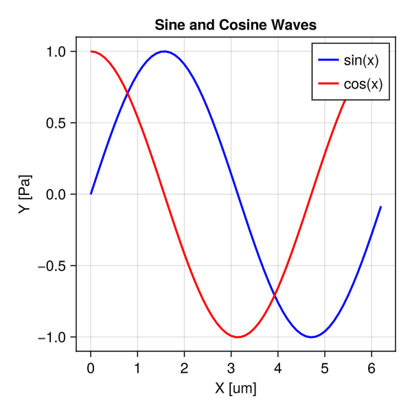

```julia
using GLMakie, DataFrames #using GLMakie, CairoMakie,

# Activate CairoMakie for saving vector graphics like PDF
GLMakie.activate!() #CairoMakie.activate!()

# Create some sample data
x = 0:0.1:2pi
y_sin = sin.(x)
y_cos = cos.(x)

# Create a DataFrame (optional, but useful to show now rather that later)
df = DataFrame(X=x, SinY=y_sin, CosY=y_cos)

# Create the plot figure and axis
fig1 = Figure(size = (400, 400))
ax = Axis(fig1[1, 1], xlabel = "X [um]", ylabel = "Y [Pa]",
          title = "Sine and Cosine Waves")

# Plot the lines
lines!(ax, df.X, df.SinY, label = "sin(x)", color = :blue, linewidth = 2)
lines!(ax, df.X, df.CosY, label = "cos(x)", color = :red, linewidth = 2)

axislegend(ax) # Add a legend

# Show the plot in an interactive window (uses GLMakie backend)
# GLMakie.activate!() # GLMakie is often the default interactive backend
#display(fig) # Or just `fig` as the last line in a Quarto cell

# Save the plot as a PDF (uses CairoMakie backend)
# Ensure CairoMakie is active if you uncomment this
# CairoMakie.activate!()
# save("plot.pdf", fig) # This would save to the current directory (tutorials/)
fig1
```

## WGLMakie Plots

Here is a fancier bit of code:

```julia
using WGLMakie

WGLMakie.activate!()
x = y = z = 1..10 # start, stop, intervl
x_r = y_r = z_r = 1:10
f(x, y, z) = x^2 + y^2 + z^2
vol = [f(ix, iy, iz) for ix in x_r, iy in y_r, iz in z_r]
fig2 = Figure(size = (400,400))
ax2 = Axis3(fig2[1,1]; perspectiveness = 0.5, azimuth = 2.19,
    elevation = 0.57, aspect = (1, 1, 1))
contour!(ax2, x, y, z, vol; levels = 10, colormap = :Egypt, transparency = true)
fig2
```

[interactive chart not shown]

Figure 1: A Makie Plot